# Introduction to the barcodeMineR package

**NOTE: This is a temporary GitHub repository created for testing purposes.**

The *barcodeMineR* package allows to recover DNA barcodes from a vector of taxonomic names. The most basic usage consists in the recovery of the taxonomic information first, followed by the download of all records available. The function [get_ncbi_taxonomy](https://matteoce.github.io/barcodeMineR/reference/get_ncbi_taxonomy.html) does exactly that:

```r
library(barcodeMineR)

# search taxonomic information for a species on the NCBI
tax <- get_ncbi_taxonomy("Dissostichus mawsoni")
tax
```

```
##              queryName taxid    rank       scientificName   phylum       class
## 1 Dissostichus mawsoni 36200 species Dissostichus mawsoni Chordata Actinopteri
##         order        family        genus              species
## 1 Perciformes Nototheniidae Dissostichus Dissostichus mawsoni
```

Taxonomic information for the species *Dissostichus mawsoni* is available at the NCBI taxonomy database, and we obtained a data frame class object with basic information regarding it.

This object can be used for the next command, which will retrieve all DNA barcodes available corresponding to this species at the NCBI nucleotide database. One of the main features of the next function consists in separating the different CDS and rRNA products of each accession number. You can leave the argument *ask* to default (TRUE) and wait to be asked to choose which CDS/rRNA to select. For now, we leave this to FALSE, so we retain automatically all CDS/rRNA features:

```r
rec_NCBI <- download_ncbi(tax, ask = FALSE)
```

Now we have the final *refdb* formatted data frame including all DNA barcodes available at the NCBI for the species *Dissostichus mawsoni*.

```
## # A tibble: 192 × 30
##    recordID   markerCode DNA_seq  phylum class order family genus species source
##    <chr>      <chr>      <DNA>    <chr>  <chr> <chr> <chr>  <chr> <chr>   <chr>
##  1 HM422302.1 COI        CTCTACT… Chord… Acti… Perc… Notot… Diss… Dissos… NCBI
##  2 ON000293.1 COX1       GCGCCTG… Chord… Acti… Perc… Notot… Diss… Dissos… NCBI
##  3 MK843765.1 COI        TCTCTAC… Chord… Acti… Perc… Notot… Diss… Dissos… NCBI
##  4 DQ498816.1 Cytb       GCCACCC… Chord… Acti… Perc… Notot… Diss… Dissos… NCBI
##  5 DQ498794.1 Rhod       GCCTACA… Chord… Acti… Perc… Notot… Diss… Dissos… NCBI
##  6 MK500763.1 enc1       TCTGACG… Chord… Acti… Perc… Notot… Diss… Dissos… NCBI
##  7 MG729451.1 COI        GAACTTA… Chord… Acti… Perc… Notot… Diss… Dissos… NCBI
##  8 KY656477.1 COI        GCCGGAA… Chord… Acti… Perc… Notot… Diss… Dissos… NCBI
##  9 LC138011.1 ND1        ATGCTTT… Chord… Acti… Perc… Notot… Diss… Dissos… NCBI
## 10 LC138011.1 ND2        ATGAGCC… Chord… Acti… Perc… Notot… Diss… Dissos… NCBI
## # ℹ 182 more rows
## # ℹ 20 more variables: lat <dbl>, lon <dbl>, lengthGene <int>, sampleID <chr>,
## #   QueryName <chr>, identified_by <chr>, taxNotes <lgl>, db_xref <chr>,
## #   sourceID <chr>, NCBI_ID <chr>, institutionStoring <lgl>,
## #   collected_by <chr>, collection_date <chr>, altitude <lgl>, depth <lgl>,
## #   country <lgl>, directionPrimers <chr>, lengthSource <int>,
## #   PCR_primers <chr>, note <chr>
```

This data frame includes 192 records (rows). However, if we were to search for all *Dissostichus mawsoni* records on the NCBI nucleotide database, using the same default filters called inside the *barcodeMineR* functions, we will notice that there are less accession numbers than the number of records obtained by the [download_ncbi](https://matteoce.github.io/barcodeMineR/reference/download_ncbi.html) function:

```r
# the default filters exclude whole genome shotgun sequences and transcribed
# shotgun assembly products
rentrez::entrez_search(db="nucleotide", term="(((txid36200[ORGN] NOT wgs[Keyword]) NOT tsa[Keyword]) AND biomol_genomic[PROP]) AND (cds[Feature key] OR rrna[Feature key])")
```

```
## Entrez search result with 131 hits (object contains 20 IDs and no web_history object)
##  Search term (as translated):  (((txid36200[ORGN] NOT wgs[Keyword]) NOT tsa[Keywo ...
```

The package recovered every single DNA barcode/gene/product available for the accession numbers corresponding to *Dissostichus mawsoni*, thus, for example, for the accession number ‘LC138011.1’ we obtained both ND1 and ND2 markers as separate records in the *refdb* data frame.

In case you want to choose which marker to keep in the final tibble, set the *ask* argument to TRUE (default), and, when asked, choose which marker to download data for:

```r
rec_NCBI <- download_ncbi(tax)
```

```
## # A tibble: 43 × 2
##    Gene_value     n
##    <chr>      <int>
##  1 COI            8
##  2 Dyst           3
##  3 myh6           3
##  4 ND2            3
##  5 tbr1           3
##  6 LDHA           2
##  7 ND4            2
##  8 Ptr            2
##  9 Rhod           2
## 10 TMO-4C4        2
## 11 ATPase 6       1
## 12 ATPase 8       1
```

[output cut: 31 more lines]

```
##
## Indicate the row numbers corresponding to the CDS and rRNA of interest.
##         (0 will return none, other inputs will return all of them)
```

```
## # A tibble: 63 × 2
##    Product_value                                                        n
##    <chr>                                                            <int>
##  1 16S ribosomal RNA                                                   33
##  2 cytochrome oxidase subunit I                                        14
##  3 cytochrome b                                                         6
##  4 NADH dehydrogenase subunit 2                                         5
##  5 hepcidin                                                             4
##  6 immunoglobulin M heavy chain                                         4
##  7 28S ribosomal RNA                                                    3
##  8 12S ribosomal RNA                                                    2
##  9 AFGP polyprotein precursor                                           2
## 10 chimeric AFGP/trypsinogen-like serine protease precursor             2
## 11 trypsinogen-like protease 1                                          2
## 12 18S ribosomal RNA                                                    1
```

[output cut: 51 more lines]

```
##
## Indicate the row numbers corresponding to the CDS and rRNA of interest.
##         (0 will return none, other inputs will return all of them)
```

The DNA barcodes will be in their 5’-to-3’ direction and of the correct length defined by the [INSDC location descriptor](https://www.insdc.org/submitting-standards/feature-table/#3.4.3), as they’ve been extracted from the single fasta sequence of the same accession number.

The same procedure can be applied using the functions querying the BOLD database, which have the same naming style. Here, we’re retrieving the taxonomy information from the BOLD database for the same species:

```r
# search taxonomic information for a species on BOLD
tax <- get_bold_taxonomy("Dissostichus mawsoni")
tax
```

```
##              queryName taxid                taxon    rank records
## 1 Dissostichus mawsoni 77420 Dissostichus mawsoni species      21
```

The output is slightly different from the output of [get_ncbi_taxonomy](https://matteoce.github.io/barcodeMineR/reference/get_ncbi_taxonomy.html), however, it serves the same role. In fact, it can then be used to download all *Dissostichus mawsoni* records from the BOLD database.

```r
rec_BOLD <- download_bold(tax, ask = FALSE)
rec_BOLD
```

```
## # A tibble: 19 × 30
##    recordID    markerCode DNA_seq phylum class order family genus species source
##    <chr>       <chr>      <DNA>   <chr>  <chr> <chr> <chr>  <chr> <chr>   <chr>
##  1 ANGBF23589… COI-5P     GCCGGA… Chord… Acti… Perc… Notot… Diss… Dissos… BOLD
##  2 ANGBF23590… COI-5P     GAACTT… Chord… Acti… Perc… Notot… Diss… Dissos… BOLD
##  3 ANTFI127-06 COI-5P     ------… Chord… Acti… Perc… Notot… Diss… Dissos… BOLD
##  4 ANTFI160-06 COI-5P     --TCTC… Chord… Acti… Perc… Notot… Diss… Dissos… BOLD
##  5 EATFR006-12 Rho        GGTGCC… Chord… Acti… Perc… Notot… Diss… Dissos… BOLD
##  6 EATFR006-12 COI-5P     ------… Chord… Acti… Perc… Notot… Diss… Dissos… BOLD
##  7 EMRKT082-07 COI-5P     NCTCTA… Chord… Acti… Perc… Notot… Diss… Dissos… BOLD
##  8 FNZ726-06   COI-5P     -CTCTA… Chord… Acti… Perc… Notot… Diss… Dissos… BOLD
##  9 FNZ727-06   COI-5P     -CTCTA… Chord… Acti… Perc… Notot… Diss… Dissos… BOLD
## 10 FNZ728-06   COI-5P     -CTCTA… Chord… Acti… Perc… Notot… Diss… Dissos… BOLD
## 11 FNZ969-07   COI-5P     TCTCTA… Chord… Acti… Perc… Notot… Diss… Dissos… BOLD
## 12 FNZC284-09  COI-5P     -CTCTA… Chord… Acti… Perc… Notot… Diss… Dissos… BOLD
## 13 GBMNA17173… COI-5P     GTGGCC… Chord… Acti… Perc… Notot… Diss… Dissos… BOLD
## 14 GBMNB8127-… COI-5P     TCTCTA… Chord… Acti… Perc… Notot… Diss… Dissos… BOLD
## 15 GBMNF47574… COI-5P     GCGCCT… Chord… Acti… Perc… Notot… Diss… Dissos… BOLD
## 16 OCARH832-12 COI-5P     --TCTC… Chord… Acti… Perc… Notot… Diss… Dissos… BOLD
## 17 OCARH904-12 COI-5P     --TCTC… Chord… Acti… Perc… Notot… Diss… Dissos… BOLD
## 18 OCARH973-12 COI-5P     --TCTC… Chord… Acti… Perc… Notot… Diss… Dissos… BOLD
## 19 OCARH981-12 COI-5P     --TCTC… Chord… Acti… Perc… Notot… Diss… Dissos… BOLD
## # ℹ 20 more variables: lat <dbl>, lon <dbl>, lengthGene <int>, sampleID <chr>,
## #   QueryName <chr>, identified_by <chr>, taxNotes <lgl>, db_xref <chr>,
## #   sourceID <chr>, NCBI_ID <chr>, institutionStoring <chr>,
## #   collected_by <chr>, collection_date <lgl>, altitude <int>, depth <int>,
## #   country <chr>, directionPrimers <chr>, lengthSource <int>,
## #   PCR_primers <chr>, note <chr>
```

We have retrieved 19 records from the BOLD database, corresponding to 18 different process-IDs. BOLD hosts other markers, but the vast majority of records correspond to Cytochrome c oxidase I sequences.

Searching species names, or taxa in general, using the [taxonomy functions](https://matteoce.github.io/barcodeMineR/reference/index.html#taxonomy) follows a set of rules that is described in the vignette “[Searching taxonomy](https://matteoce.github.io/barcodeMineR/articles/taxonomy_barcodeMineR.html)”.

## Merging data from different repositories

We can now merge both *refdb* data frames to obtain a single one. The default behaviour of the next function will check which records have been mined from the other repository and return only the original record. If needed, this behaviour can be switched off by setting the argument *resolve.conflicts* to FALSE:

```r
total <- mergeBarcodeOres(rec_NCBI, rec_BOLD)
```

```
## '5' records from BOLD were mined from the NCBI.
## If they are already represented by the NCBI barcodeOre they will be removed to avoid duplicates.
```

```
## '3' records from NCBI were mined from BOLD.
## If they are already represented by the BOLD barcodeOre they will be removed to avoid duplicates.
## Duplicated records obtained from the BOLD will be kept.
```

As we can see from the printed messages, some records were actually mined versions of other records obtained from the other repository. They have been removed after checking that the original version was downloaded from the opposite repository.

```r
total
```

```
## # A tibble: 203 × 30
##    recordID   markerCode DNA_seq  phylum class order family genus species source
##    <chr>      <chr>      <DNA>    <chr>  <chr> <chr> <chr>  <chr> <chr>   <chr>
##  1 ON000293.1 COX1       GCGCCTG… Chord… Acti… Perc… Notot… Diss… Dissos… NCBI
##  2 MK843765.1 COI        TCTCTAC… Chord… Acti… Perc… Notot… Diss… Dissos… NCBI
##  3 DQ498816.1 Cytb       GCCACCC… Chord… Acti… Perc… Notot… Diss… Dissos… NCBI
##  4 DQ498794.1 Rhod       GCCTACA… Chord… Acti… Perc… Notot… Diss… Dissos… NCBI
##  5 MK500763.1 enc1       TCTGACG… Chord… Acti… Perc… Notot… Diss… Dissos… NCBI
##  6 MG729451.1 COI        GAACTTA… Chord… Acti… Perc… Notot… Diss… Dissos… NCBI
##  7 KY656477.1 COI        GCCGGAA… Chord… Acti… Perc… Notot… Diss… Dissos… NCBI
##  8 LC138011.1 ND1        ATGCTTT… Chord… Acti… Perc… Notot… Diss… Dissos… NCBI
##  9 LC138011.1 ND2        ATGAGCC… Chord… Acti… Perc… Notot… Diss… Dissos… NCBI
## 10 LC138011.1 COI        GTGGCCA… Chord… Acti… Perc… Notot… Diss… Dissos… NCBI
## # ℹ 193 more rows
## # ℹ 20 more variables: lat <dbl>, lon <dbl>, lengthGene <int>, sampleID <chr>,
## #   QueryName <chr>, identified_by <chr>, taxNotes <lgl>, db_xref <chr>,
## #   sourceID <chr>, NCBI_ID <chr>, institutionStoring <chr>,
## #   collected_by <chr>, collection_date <chr>, altitude <int>, depth <int>,
## #   country <chr>, directionPrimers <chr>, lengthSource <int>,
## #   PCR_primers <chr>, note <chr>
```

This is it, now we have all DNA barcodes available on the major online repositories for the species *Dissostichus mawsoni*.

In case we want to add additional, private sequences to the mined results, we can use the function [loadBarcodeOre](https://matteoce.github.io/barcodeMineR/reference/loadBarcodeOre.html) and specify either the paths to a tsv file and a fasta file including our new sequences, or to a data frame and a *DNAStringSet* object with the same, to output a *refdb* data frame formatted as those we merged earlier.

In order to do that, the tsv file must include the same fields (*i.e.* column names) included in the example dataset object *example_record*.

```r
# load example datasets from barcodeMineR...
rec <- barcodeMineR::example_record
seq <- barcodeMineR::example_sequence

#... or include the path to your files
rec <- "~/home/my/path/data.tsv"
seq <- "~/home/my/path/data.fasta"

new_records <- loadBarcodeOre(rec, seq)
new_records
```

```
## # A tibble: 1 × 30
##   recordID markerCode DNA_seq     phylum class order family genus species source
##   <chr>    <chr>      <DNA>       <chr>  <chr> <chr> <chr>  <chr> <chr>   <chr>
## 1 SEQ_01   COI        AAACTCAAAG… Chord… Acti… Perc… Notot… Diss… Dissos… ACRON…
## # ℹ 20 more variables: lat <dbl>, lon <dbl>, lengthGene <int>, sampleID <chr>,
## #   QueryName <chr>, identified_by <chr>, taxNotes <chr>, db_xref <chr>,
## #   sourceID <chr>, NCBI_ID <chr>, institutionStoring <chr>,
## #   collected_by <chr>, collection_date <chr>, altitude <chr>, depth <dbl>,
## #   country <chr>, directionPrimers <chr>, lengthSource <int>,
## #   PCR_primers <chr>, note <chr>
```

We can merge these records with the ones we mined online and examine all results:

```r
total <- mergeBarcodeOres(total, new_records)
```

```
## No records were obtained from both the NCBI and BOLD
```

```r
total
```

```
## # A tibble: 204 × 30
##    recordID   markerCode DNA_seq  phylum class order family genus species source
##    <chr>      <chr>      <DNA>    <chr>  <chr> <chr> <chr>  <chr> <chr>   <chr>
##  1 ON000293.1 COX1       GCGCCTG… Chord… Acti… Perc… Notot… Diss… Dissos… NCBI
##  2 MK843765.1 COI        TCTCTAC… Chord… Acti… Perc… Notot… Diss… Dissos… NCBI
##  3 DQ498816.1 Cytb       GCCACCC… Chord… Acti… Perc… Notot… Diss… Dissos… NCBI
##  4 DQ498794.1 Rhod       GCCTACA… Chord… Acti… Perc… Notot… Diss… Dissos… NCBI
##  5 MK500763.1 enc1       TCTGACG… Chord… Acti… Perc… Notot… Diss… Dissos… NCBI
##  6 MG729451.1 COI        GAACTTA… Chord… Acti… Perc… Notot… Diss… Dissos… NCBI
##  7 KY656477.1 COI        GCCGGAA… Chord… Acti… Perc… Notot… Diss… Dissos… NCBI
##  8 LC138011.1 ND1        ATGCTTT… Chord… Acti… Perc… Notot… Diss… Dissos… NCBI
##  9 LC138011.1 ND2        ATGAGCC… Chord… Acti… Perc… Notot… Diss… Dissos… NCBI
## 10 LC138011.1 COI        GTGGCCA… Chord… Acti… Perc… Notot… Diss… Dissos… NCBI
## # ℹ 194 more rows
## # ℹ 20 more variables: lat <dbl>, lon <dbl>, lengthGene <int>, sampleID <chr>,
## #   QueryName <chr>, identified_by <chr>, taxNotes <chr>, db_xref <chr>,
## #   sourceID <chr>, NCBI_ID <chr>, institutionStoring <chr>,
## #   collected_by <chr>, collection_date <chr>, altitude <chr>, depth <dbl>,
## #   country <chr>, directionPrimers <chr>, lengthSource <int>,
## #   PCR_primers <chr>, note <chr>
```

## Analyzing the database

Having a pre-formatted [refdb](https://fkeck.github.io/refdb/index.html) data frame allows to use the functions of that package, including filtering operations, quality checks, examination of taxonomic conflicts and plotting functions. For example, if we were to search for taxonomic conflicts, we could use the appropriate function from the *refdb* package:

```r
library(refdb)

refdb_check_tax_conflict(total)
```

```
## $phylum
## # A tibble: 0 × 2
## # ℹ 2 variables: Taxon <chr>, Taxonomy <???>
##
## $class
## # A tibble: 0 × 2
## # ℹ 2 variables: Taxon <chr>, Taxonomy <???>
##
## $order
## # A tibble: 2 × 2
##   Taxon       Taxonomy
##   <chr>       <chr>
## 1 Perciformes Chordata > Actinopteri
## 2 Perciformes Chordata > Actinopterygii
##
## $family
## # A tibble: 2 × 2
##   Taxon         Taxonomy
##   <chr>         <chr>
## 1 Nototheniidae Chordata > Actinopteri > Perciformes
## 2 Nototheniidae Chordata > Actinopterygii > Perciformes
##
## $genus
## # A tibble: 2 × 2
##   Taxon        Taxonomy
##   <chr>        <chr>
## 1 Dissostichus Chordata > Actinopteri > Perciformes > Nototheniidae
## 2 Dissostichus Chordata > Actinopterygii > Perciformes > Nototheniidae
##
## $species
## # A tibble: 2 × 2
##   Taxon                Taxonomy
##   <chr>                <chr>
## 1 Dissostichus mawsoni Chordata > Actinopteri > Perciformes > Nototheniidae > D…
## 2 Dissostichus mawsoni Chordata > Actinopterygii > Perciformes > Nototheniidae …
```

We can also filter records based on the length of the sequences. Although we retain this information in the lengthGene field, the *refdb* package directly calculates it using the [refdb_filter_seq_length](https://fkeck.github.io/refdb/reference/refdb_filter_seq_length.html) function. Let’s say we want to know how many records correspond to a maximum of 658 base pairs (bp) in length:

```r
total_filt <- refdb_filter_seq_length(total, max_len = 658)
```

A total of 99 records include sequences up to 658 bp in length. However, many records results much shorter than this length:

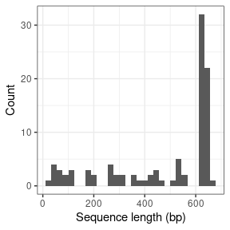

```r
refdb_plot_seqlen_hist(total_filt)
```

In fact, many records have been extracted from complete mitochondrial genomes, and this can be readily inspected by using one of the plotting functions of the *barcodeMineR* package:

[figure not shown]

```r
plot_length(total_filt)
```

As shown, the original length of the fasta sequence of some records is much longer than the final result obtained with the *barcodeMineR* package.

Not much information was retrieved from each record, but we can see how many records include the primers used to amplify their sequence with another plotting function of the *barcodeMineR* package, credit by [Gwiazdowski et al. (2015)](https://journals.plos.org/plosone/article/file?id=10.1371/journal.pone.0125635&type=printable):

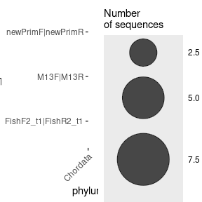

```r
plot_primers(total_filt)
```

We can also map the records with available geographical coordinates using the *refdb* package:

```r
refdb_plot_map(total)
```

[interactive chart not shown]

Only a few records have geographical coordinates in the final merged table.

This is the basic usage of the **barcodeMineR** package. Now you can check how to speed up the recovery of records from the NCBI database by reading this [vignette](https://matteoce.github.io/barcodeMineR/articles/api_rate_barcodeMineR.html).